# Lab5_jeanniecarreiro

Jeannie Carreiro

9/25/2020

```r
rm(list=ls())
library(tidyverse)
options(max.print=1000)
```

# interactive covid reporting

Revise the above example for joining tables using 6/13/2020 and 9/13/2020.

```r
confirmed_state_06_13_2020 <-   read_csv(url("https://raw.githubusercontent.com/CSSEGISandData/COVID-19/master/csse_covid_19_data/csse_covid_19_daily_reports/06-13-2020.csv")) %>%
  filter(Country_Region == 'US') %>%
  group_by(Province_State, Country_Region) %>%
  summarise(Confirmed = sum(Confirmed))
str(confirmed_state_06_13_2020)
```

[output not shown]

[output cut: 12 more lines]

[output not shown]

```r
confirmed_state_09_13_2020 <-   read_csv(url("https://raw.githubusercontent.com/CSSEGISandData/COVID-19/master/csse_covid_19_data/csse_covid_19_daily_reports/09-13-2020.csv")) %>%
  filter(Country_Region == 'US') %>%
  group_by(Province_State, Country_Region) %>%
  summarise(Confirmed = sum(Confirmed))
str(confirmed_state_09_13_2020)
```

[output not shown]

[output cut: 12 more lines]

[output not shown]

```r
setdiff(confirmed_state_09_13_2020$Province_State, confirmed_state_06_13_2020$Province_State)
```

```
## character(0)
```

```r
# output character(0) since there are equal amount of states in each table so we can move on

# we dont need recovered

confirmed_state_09_13_2020 <- confirmed_state_09_13_2020 %>%
  filter(Province_State != 'Recovered')

confirmed_state_joined <- full_join(confirmed_state_06_13_2020, confirmed_state_09_13_2020, by = c('Province_State'))

head(confirmed_state_joined)
```

```
## # A tibble: 6 x 5
## # Groups:   Province_State [6]
##   Province_State Country_Region.x Confirmed.x Country_Region.y Confirmed.y
##   <chr>          <chr>                  <dbl> <chr>                  <dbl>
## 1 Alabama        US                     24601 US                    138755
## 2 Alaska         US                       653 US                      6268
## 3 Arizona        US                     34660 US                    208512
## 4 Arkansas       US                     12095 US                     70219
## 5 California     US                    150018 US                    761728
## 6 Colorado       US                     29002 US                     61293
```

```r
tail(confirmed_state_joined, 5)
```

```
## # A tibble: 5 x 5
## # Groups:   Province_State [5]
##   Province_State Country_Region.x Confirmed.x Country_Region.y Confirmed.y
##   <chr>          <chr>                  <dbl> <chr>                  <dbl>
## 1 Virginia       US                     53869 US                    133742
## 2 Washington     US                     25538 US                     79826
## 3 West Virginia  US                      2274 US                     12705
## 4 Wisconsin      US                     22518 US                     89185
## 5 Wyoming        US                      1050 US                      4346
```

```r
# or

which(is.na(confirmed_state_joined))
```

```
## [1] 219 277
```

```r
# change the na to 0s, rename confirmed and delete country_region columns

confirmed_state_joined <- full_join(confirmed_state_06_13_2020, confirmed_state_09_13_2020, by = c('Province_State')) %>%
  rename(Confirmed_06_13_2020 = 'Confirmed.x', Confirmed_09_13_2020 = 'Confirmed.y') %>%
  select(-Country_Region.x, -Country_Region.y) %>%
  replace_na(list(Confirmed_06_13_2020 = 0)) %>%
  replace_na(list(Confirmed_09_13_2020 = 0))
head(confirmed_state_joined)
```

```
## # A tibble: 6 x 3
## # Groups:   Province_State [6]
##   Province_State Confirmed_06_13_2020 Confirmed_09_13_2020
##   <chr>                         <dbl>                <dbl>
## 1 Alabama                       24601               138755
## 2 Alaska                          653                 6268
## 3 Arizona                       34660               208512
## 4 Arkansas                      12095                70219
## 5 California                   150018               761728
## 6 Colorado                      29002                61293
```

```r
which(is.na(confirmed_state_joined))
```

```
## integer(0)
```

switching between wide and long table formats

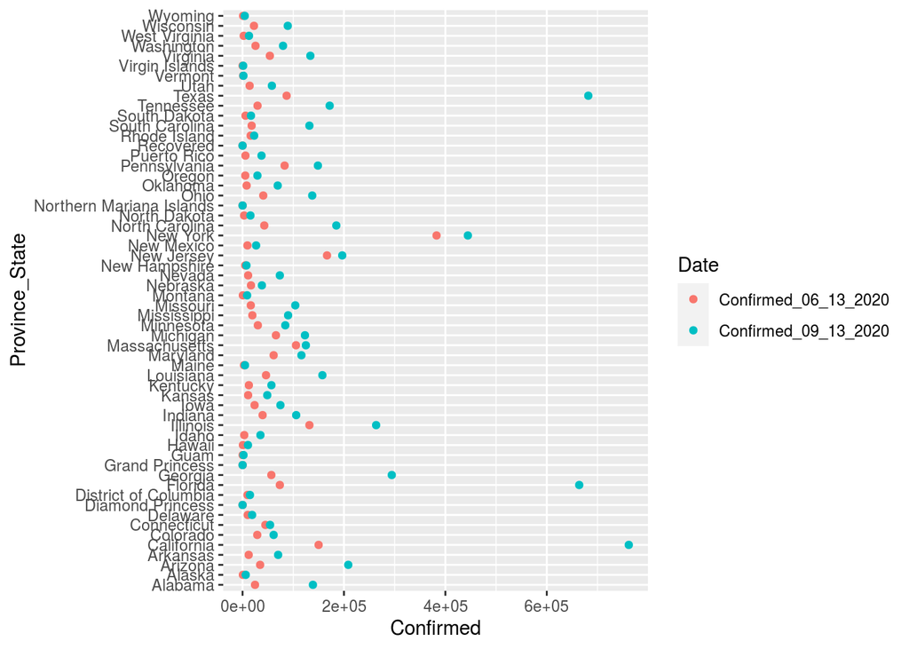

```r
confirmed_state_joined_long <- confirmed_state_joined %>%
  pivot_longer(-c(Province_State),
               names_to = 'Date', values_to = 'Confirmed')

# use this table in plot which shows the confirmed cases for both dates

ggplot(confirmed_state_joined_long, aes(x = Confirmed, y = Province_State)) +
  geom_point(aes(color = Date))
```

Plot the data as a bar plot. Make sure your graph looks nice in the report by adjusting the height in the R code chunk header.

Add more informative x and y labels and a title to the graph.

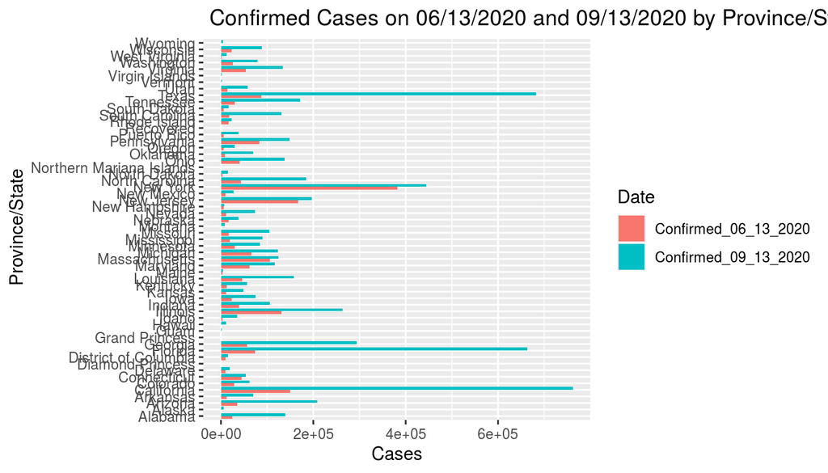

```r
ggplot(confirmed_state_joined_long, aes(x = Confirmed, y = Province_State, fill = Date)) +
  geom_bar(stat = "identity", position = position_dodge()) +
  labs(title = ' Confirmed Cases on 06/13/2020 and 09/13/2020 by Province/State', x = 'Cases', y = ' Province/State')
```

Using the time series data. Make a plot of the total number of confirmed deaths per day worldwide

```r
time_series_confirmed <- read_csv(url("https://raw.githubusercontent.com/CSSEGISandData/COVID-19/master/csse_covid_19_data/csse_covid_19_time_series/time_series_covid19_confirmed_global.csv")) %>%
  rename(Province_State = "Province/State", Country_Region = "Country/Region")
time_series_confirmed_long <- time_series_confirmed %>%
               pivot_longer(-c(Province_State, Country_Region, Lat, Long),
                            names_to = "Date", values_to = "Confirmed")

download.file(url="https://raw.githubusercontent.com/CSSEGISandData/COVID-19/master/csse_covid_19_data/csse_covid_19_time_series/time_series_covid19_deaths_global.csv",
               destfile = "data/time_series_covid19_deaths_global.csv")

time_series_deaths <- read_csv("data/time_series_covid19_deaths_global.csv")%>%
  rename(Province_State = "Province/State", Country_Region = "Country/Region")
time_series_deaths_long <- time_series_deaths %>%
               pivot_longer(-c(Province_State, Country_Region, Lat, Long),
                            names_to = "Date", values_to = "Deaths")

time_series_confirmed_long <- time_series_confirmed_long %>%
  unite(Key, Province_State, Country_Region, Date, sep = ".", remove = FALSE)

time_series_deaths_long <- time_series_deaths_long %>%
  unite(Key, Province_State, Country_Region, Date, sep = ".") %>%
  select(Key, Deaths)

time_series_long_joined <- full_join(time_series_confirmed_long,
              time_series_deaths_long, by = c("Key")) %>%
              select(-Key)

library(lubridate)
```

```r
time_series_long_joined$Date <- mdy(time_series_long_joined$Date)

# use since we will want to plot both confirmed and deaths on the same graph

time_series_long_joined_counts <- time_series_long_joined %>%
  pivot_longer(-c(Province_State, Country_Region, Lat, Long, Date),
               names_to = "Report_Type", values_to = "Counts")
```

Make a plot of the total number of confirmed deaths per day worldwide

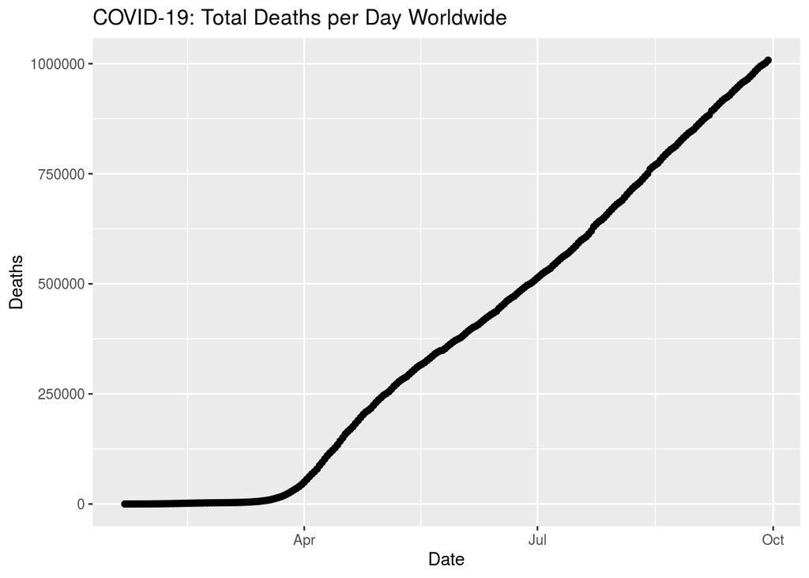

```r
time_series_long_joined %>%
  group_by(Date) %>%
  summarise_at(c('Confirmed', 'Deaths'), sum) %>%
  ggplot(aes(x = Date, y = Deaths)) +
  geom_point() +
  geom_line() +
  ggtitle('COVID-19: Total Deaths per Day Worldwide')
```

Use Mutate to make a new column with deaths/confirmed cases (Hint: this might be best done after joining the tables, but before pivoting longer)

```r
view(time_series_long_joined)

time_series_long_joined_mutated <- time_series_long_joined %>%
  mutate(deathsperconfirmed = Deaths / Confirmed) %>%
  filter(!is.na(deathsperconfirmed))
```

Plot US deaths/confirmed cases per day

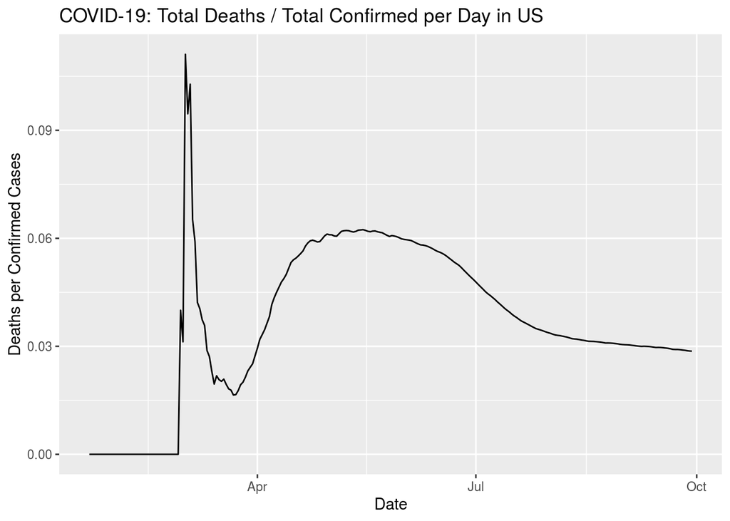

```r
time_series_long_joined_mutated %>%
  group_by(Date, Country_Region) %>%
  summarise_at(c('deathsperconfirmed'), sum) %>%
  filter(Country_Region %in% c('US')) %>%
  ggplot(aes(x = Date, y = deathsperconfirmed)) +
  geom_line() +
  ggtitle('COVID-19: Total Deaths / Total Confirmed per Day in US') +
  labs(y = 'Deaths per Confirmed Cases')
```

Make a single graph with from the times series data with the 10 countries with the hightest death total.

```r
top_deaths_per_country <-
  time_series_long_joined %>%
  group_by(Country_Region) %>%
  summarize(totalDeaths = sum(Deaths)) %>%
  arrange(desc(totalDeaths)) %>%
  slice(1:10)
```

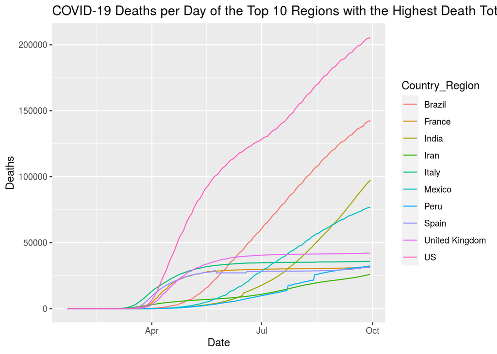

```r
view(top_deaths_per_country)

time_series_long_joined %>%
    group_by(Country_Region,Date) %>%
    summarise_at(c("Confirmed", "Deaths"), sum) %>%
    filter (Country_Region %in% c("US","Brazil","United Kingdom", "Italy", "Mexico", "India", "France", "Spain", "Iran", "Peru")) %>%
    ggplot(aes(x = Date,  y = Deaths, color = Country_Region)) +
    geom_line() +
    ggtitle("COVID-19 Deaths per Day of the Top 10 Regions with the Highest Death Total ")
```

Using Facet_Wraps make a graph from the times series data with the 10 countries with the hightest death total. Format the table to look nice in the report by changing the number of rows in your graph and/or adjusting the height in the R code chunk header.

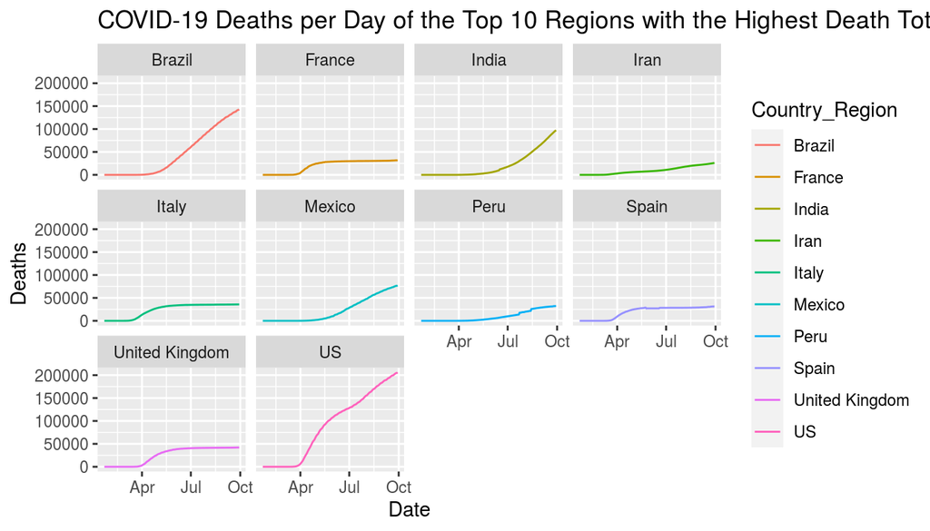

```r
time_series_long_joined %>%
    group_by(Country_Region,Date) %>%
    summarise_at(c("Confirmed", "Deaths"), sum) %>%
    filter (Country_Region %in% c("US","Brazil","United Kingdom", "Italy", "Mexico", "India", "France", "Spain", "Iran", "Peru")) %>%
    ggplot(aes(x = Date,  y = Deaths, color = Country_Region)) +
    geom_line() +
    ggtitle("COVID-19 Deaths per Day of the Top 10 Regions with the Highest Death Total ") +
  facet_wrap(facets = vars(Country_Region))
```

[figure not shown]

```r
time_series_long_joined %>%
    group_by(Country_Region, Province_State, Date) %>%
    summarise_at(c("Confirmed", "Deaths"), sum) %>%
    filter (Country_Region == 'US') %>%
    ggplot(aes(x = Date,  y = Confirmed,)) +
    geom_point() +
    geom_line() +
    ggtitle("COVID-19 Deaths by Province/State") +
  facet_wrap(facets = vars(Province_State))
```

Apply a theme other than the one used in the Data Carpentries tutorial to the graph in Ex8.

```r
top_deaths_per_country <-
  time_series_long_joined %>%
  group_by(Country_Region) %>%
  summarize(totalDeaths = sum(Deaths)) %>%
  arrange(desc(totalDeaths)) %>%
  slice(1:10)
```

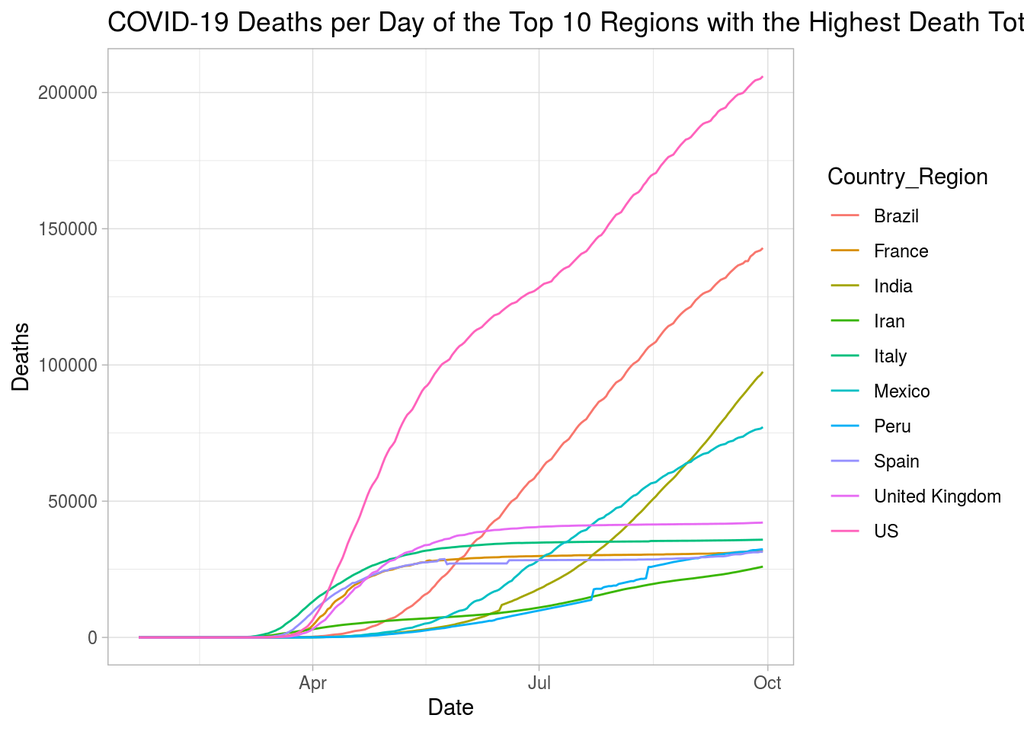

```r
view(top_deaths_per_country)

time_series_long_joined %>%
    group_by(Country_Region,Date) %>%
    summarise_at(c("Confirmed", "Deaths"), sum) %>%
    filter (Country_Region %in% c("US","Brazil","United Kingdom", "Italy", "Mexico", "India", "France", "Spain", "Iran", "Peru")) %>%
    ggplot(aes(x = Date,  y = Deaths, color = Country_Region)) +
    geom_line() +
    ggtitle("COVID-19 Deaths per Day of the Top 10 Regions with the Highest Death Total ") +
  theme_light()
```